← AN05B023a-d scenes

# AN05B023a-d: dimorphic partners, by volume

## What this asks

The pair pages each answer “which of these two sends more of its output to dimorphic or sex-specific partners” for one pair. This asks it of the whole AN05B023 family at once, so the members are ranked against each other rather than two at a time.

Each member is fetched separately and normalised by its own total output, so `frac` is a share and members of different sizes stay comparable.

```r
options(rgl.useNULL = TRUE)   # must precede any library that pulls rgl in (nat)

suppressMessages({
  library(neuprintr); library(malecns); library(nat)
  library(coconatfly); library(coconat)
  options(malecns.dataset = "male-cns:v1.0")   # malecns helpers ignore MCNS_DATASET
  library(dplyr); library(tibble)
  library(ggplot2); library(ggrepel); library(scales); library(patchwork)
})

R_DIR <- "/Users/fkampf/Documents/pheromone.paper/analyses/an_investigation/R"

Sys.setenv(AN_CASE = "an05b023bc")   # only for FOCUS and the palettes
source(file.path(R_DIR, "_paths.R"))
source(file.path(R_DIR, "_an_pair.R"))
neuprint_login(server = MCNS_SERVER, dataset = MCNS_DATASET)
```

```r
load_once <- function(name, expr, envir = .GlobalEnv) {
  # eval() here evaluates a quote()d expression written literally in this file -
  # a lazy-evaluation idiom for "only fetch if not already cached", not a parser
  # of external input.
  if (!exists(name, envir = envir, inherits = FALSE)) {
    assign(name, eval(expr), envir = envir)
  }
  get(name, envir = envir)
}

mba <- load_once("mba", quote(mcns_body_annotations()))

contact_pool <- sensory_pool(mba)

MEMBERS <- sort(unique(grep("^AN05B023[a-z]$", mba$type, value = TRUE)))
MEMBERS
```

```
## [1] "AN05B023a" "AN05B023b" "AN05B023c" "AN05B023d"
```

## Whole reconstruction

```r
fam <- dimorph_output_family(MEMBERS, mba, contact_pool)

fam |>
  filter(dimorphism != "not annotated") |>
  summarise(annotated_share = sum(frac), synapses = sum(synapses),
            partner_types = sum(partner_types), .by = member)
```

| member | annotated_share | synapses | partner_types |
| --- | --- | --- | --- |
| AN05B023a | 0.1167908 | 690 | 15 |
| AN05B023b | 0.1030566 | 499 | 19 |
| AN05B023c | 0.1387192 | 1317 | 66 |
| AN05B023d | 0.1597913 | 1991 | 90 |

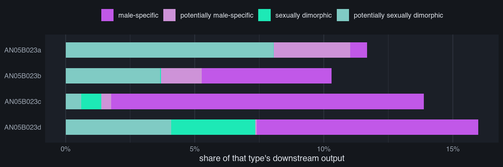

```r
dimorph_family_plot(fam, MEMBERS)
```

## VNC only

The whole-reconstruction numbers are not comparable across this family, because AN05B023b is cut off in the brain — see `08_an05b023bc_cut.Rmd`. Anything a member does in the brain is missing from b by construction, so the same query restricted to the VNC is the one place all four are scored on a volume they all have.

```r
fam_vnc <- dimorph_output_family(MEMBERS, mba, contact_pool, roi = "VNC")

fam_vnc |>
  filter(dimorphism != "not annotated") |>
  summarise(annotated_share = sum(frac), synapses = sum(synapses),
            partner_types = sum(partner_types), .by = member)
```

| member | annotated_share | synapses | partner_types |
| --- | --- | --- | --- |
| AN05B023a | 0.15439372 | 629 | 12 |
| AN05B023b | 0.10052247 | 481 | 14 |
| AN05B023c | 0.01462226 | 54 | 7 |
| AN05B023d | 0.03923468 | 162 | 16 |

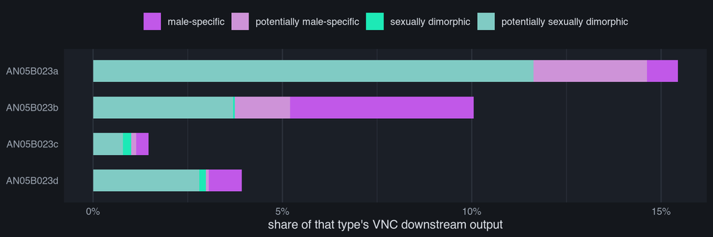

```r
dimorph_family_plot(fam_vnc, MEMBERS,
                    "share of that type's VNC downstream output")
```

## Brain only

The VNC panel says AN05B023c barely works with dimorphic partners in the nerve cord. The whole-reconstruction panel says it does about as much of it as the others. Both can be true if it does that work in the brain, and this panel is where that claim is testable. `CentralBrain` is the ROI, so the optic lobes are out.

```r
fam_brain <- dimorph_output_family(MEMBERS, mba, contact_pool,
                                   roi = "CentralBrain")

fam_brain |>
  filter(dimorphism != "not annotated") |>
  summarise(annotated_share = sum(frac), synapses = sum(synapses),
            partner_types = sum(partner_types), .by = member)
```

| member | annotated_share | synapses | partner_types |
| --- | --- | --- | --- |
| AN05B023a | 0.03275109 | 60 | 7 |
| AN05B023b | 0.31578947 | 18 | 6 |
| AN05B023c | 0.21779617 | 1263 | 64 |
| AN05B023d | 0.21954147 | 1829 | 83 |

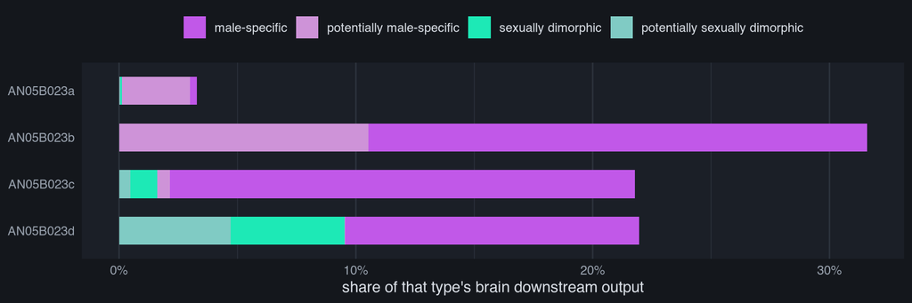

```r
dimorph_family_plot(fam_brain, MEMBERS,
                    "share of that type's brain downstream output")
```

It is testable and it holds. On the run of 2026-08-13 AN05B023c gives 21.8% of its brain output to annotated dimorphic partners, over 1263 synapses, against 1.5% in the VNC. AN05B023d is beside it at 22.0%, over 1829 synapses. AN05B023a is at 3.3%.

AN05B023b is not comparable here and its bar should not be read: its whole brain output is 57 synapses, of which 18 land on annotated dimorphic partners. The resulting 31.6% is the largest share on the panel and it means nothing, because the neuron is truncated in the brain. That is the truncation, not a result.

So the whole-reconstruction ranking is a mixture of two different behaviours, and splitting it by volume separates them: in the brain c and d are the dimorphic ones, in the VNC they are not.

A note on the arithmetic, because it changed these numbers. An ROI query returns every edge that touches the volume, but its `weight` stays the whole- reconstruction weight; the part inside the volume is `ROIweight`. Summing `weight` counts synapses that are somewhere else, and on this family it inflated the brain by 14% and the VNC by 9%. Every ROI-restricted figure and number on this page now goes through `ROIweight`.

## Brain input

The three panels above ask what a member sends. This asks what it receives, and it asks it in the brain, because that is where AN05B023c does the dimorphic work the VNC panel says it does not do in the nerve cord.

`CentralBrain` is the ROI, so the optic lobes are out. Sensory partners are dropped, as they are on the output side, so this counts central input only.

Read the denominators before the bars. On the run of 2026-08-13 the whole brain input was AN05B023a 2972 synapses, AN05B023d 575, AN05B023c 298 and AN05B023b 31. AN05B023b has no bar at all: 31 synapses, none of them from an annotated dimorphic type. So this panel compares one well-sampled member against two thinly-sampled ones, and AN05B023c’s share of 23.8% rests on 71 synapses across 19 partner types, AN05B023d’s 19.1% on 110 synapses across 31.

```r
fam_brain_in <- dimorph_input_family(MEMBERS, mba, contact_pool,
                                     roi = "CentralBrain")

fam_brain_in |>
  filter(dimorphism != "not annotated") |>
  summarise(annotated_share = sum(frac), synapses = sum(synapses),
            partner_types = sum(partner_types), .by = member)
```

| member | annotated_share | synapses | partner_types |
| --- | --- | --- | --- |
| AN05B023a | 0.006393001 | 19 | 7 |
| AN05B023c | 0.238255034 | 71 | 19 |
| AN05B023d | 0.191304348 | 110 | 31 |

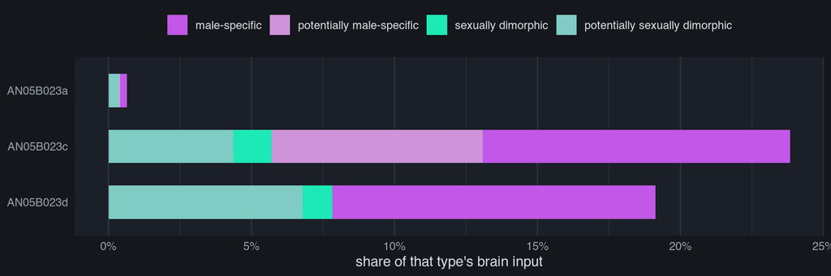

```r
dimorph_family_plot(fam_brain_in, MEMBERS,
                    "share of that type's brain input")
```

Taken with the VNC panel, AN05B023c reads the same way on both sides of the synapse: what it does with dimorphic partners, it does in the brain. AN05B023a is the mirror image, 0.6% of its brain input against a large brain input overall. The sampling on c and d is too thin to put a number on, and the sensible next step is the per-partner list rather than a larger share.

## Where these families sit among ascending neurons

That ranking is its own page now: /ng/dimorphic-ranking/. The bristle types and neuromeres that drive the dimorphic neurons are at /ng/bristle-impact/. It holds the same 177 ascending types, ranked three ways and grouped by dominant segment and by dominant bristle type, with these four marked in place.